# Анализ кредитов в ломбардах

Данные брались из базы данных программы Ломбард за период с 1 января 2018 года по июль 2019 года.  
Здесь исследуются только кредиты, (не покупки), которые в конечном итоге были погашены (выкуплены).

Управление презентацией с помощью клавиш и стрелочек:  
клавиша "HOME"- в начало; клавиша "END"- в конец;  
стрелка вправо "->" - следущий слайд; стрелка влево "<-" - предыдущий слайд;  
стрелка вниз - следущий подслайд; стрелка вверх - предыдущий подслайд.  
См. пиктограммку в правом нижнем углу, она показывает возможную навигацию.

## 1. Статистика по кредитам

```python
df_returned[['Summa', 'AmountOfPayments', 'len']].describe()
```

|  | Summa | AmountOfPayments | len |
| --- | --- | --- | --- |
| count | 39515.000000 | 39515.000000 | 39515 |
| mean | 8154.140881 | 3.210123 | 57 days 14:33:13.187397 |
| std | 14103.123053 | 8.347711 | 78 days 09:18:07.877438 |
| min | 5.600000 | 1.000000 | -1 days +00:00:00 |
| 25% | 2681.600000 | 1.000000 | 11 days 00:00:00 |
| 50% | 4581.000000 | 1.000000 | 27 days 00:00:00 |
| 75% | 8888.900000 | 3.000000 | 67 days 00:00:00 |
| max | 514433.000000 | 385.000000 | 477 days 00:00:00 |

**Где:**  
**Summa** - сумма кредита;  
**AmountOfPayments** - количество платежей платежей по кредиту. Если кредит взяли, а потом погасили (т.е. перезалогов по нему не было), то считается, как один платеж;  
**len** - общая длительность кредита в днях;  
**count** - количество;  
**mean** - среднее;  
**std** - стандартное отклонение;  
**min** - минимум;  
**25%** - первая квартиль;  
**50%** - медиана;  
**75%** - третья квартиль; **max** - максимум.

```python
df[df['AmountOfPayments'] >= 25.][['Summa', 'AmountOfPayments', 'len']].describe()
```

|  | Summa | AmountOfPayments | len |
| --- | --- | --- | --- |
| count | 592.000000 | 592.000000 | 592 |
| mean | 13572.747804 | 57.222973 | 249 days 15:21:53.513513 |
| std | 15749.966853 | 45.647783 | 97 days 11:22:49.035818 |
| min | 10.200000 | 25.000000 | 43 days 00:00:00 |
| 25% | 4221.025000 | 30.000000 | 163 days 00:00:00 |
| 50% | 8617.750000 | 41.500000 | 258 days 00:00:00 |
| 75% | 16666.700000 | 65.000000 | 332 days 00:00:00 |
| max | 152417.600000 | 385.000000 | 462 days 00:00:00 |

## 2. Статистика количество клиентов, и сколько кредитов брал клиент, за исследуемый период

```python
quant_credits_per_client.describe()
```

```
count    13033.000000
mean         3.031919
std          4.047435
min          1.000000
25%          1.000000
50%          2.000000
75%          3.000000
max        101.000000
dtype: float64
```

В данном случае count=13033 - это сколько было уникальных клиентов за период.  
Медиана, например, говорит нам, что у 50% клиентов было за этот период не более 2 кредитов.

Нажми стрелочку вниз

### 2.1. Распределение Количество кредитов на клиента

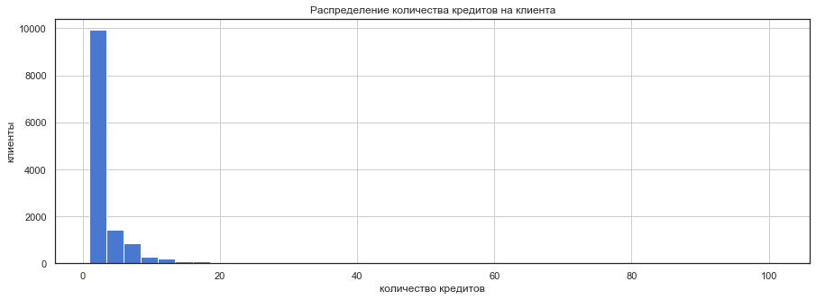

```python
quant_credits_per_client.hist(bins=40, figsize=(15,5))
plt.title('Распределение количества кредитов на клиента')
plt.ylabel('клиенты')
plt.xlabel('количество кредитов')
plt.show()
```

Нажми стрелочку вниз

### 2.2. Распределение количества кредитов на клиента, продолжение

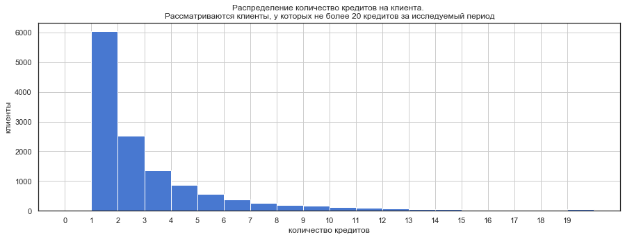

```python
quant_credits_per_client.plot(kind='hist', bins=20, figsize=(15,5), range=(0,20), grid=True); plt.xticks(np.arange(0, 20, 1))
plt.title('Распределение количество кредитов на клиента. \nРассматриваются клиенты, \
у которых не более 20 кредитов за исследуемый период')
plt.ylabel('клиенты'); plt.xlabel('количество кредитов'); plt.show()
```

Распределение количество кредитов на клиента.  
Рассматриваются клиенты, у которых не более 20 кредитов за исследуемый период

### 2.3. Статистика распределение количества кредитов на клиента, продолжение

не более 20 кредитов у клиента за период

```python
quant_credits_per_client[quant_credits_per_client <= 20].describe()
```

```
count    12914.00000
mean         2.78473
std          2.91918
min          1.00000
25%          1.00000
50%          2.00000
75%          3.00000
max         20.00000
dtype: float64
```

## 3. Статистика по повторным кредитам

Всего было кредитов за период:

```python
len(cr_interval) # Количество кредитов выданных и их вернули
```

```
39515
```

Из них повторных кредитов за период:

```python
repeat_credits
```

```
26482
```

## 3.1. Статистика по повторным кредитам

В данном случае мы рассматриваем интервалы между открытиями следующих повторных кредитов. Т.е. клиент пришел, взял кредит, и мы анализируем время, через которое он придет и откроет новый кредит. При открытии нового кредита у него могут быть незакрытые кредиты.

```python
cr_interval.describe()
```

```
count                      26482
mean     59 days 08:11:30.582282
std      72 days 15:42:30.389538
min              1 days 00:00:00
25%             14 days 00:00:00
50%             32 days 00:00:00
75%             75 days 00:00:00
max            527 days 00:00:00
Name: DateBegin, dtype: object
```

Нажми стрелочку вниз

### 3.2. Распределение интерывалов между повторными кредитами

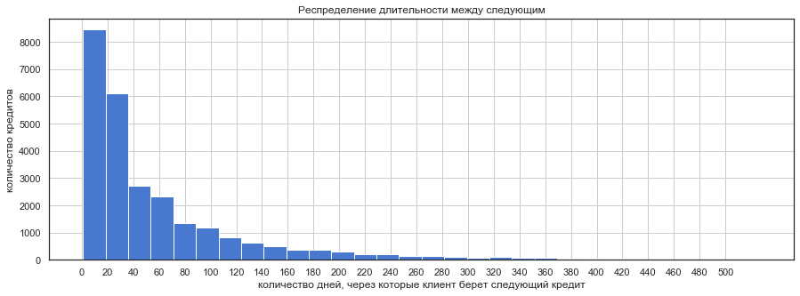

```python
interval_b_credit_ser.hist(bins=30, figsize=(15,5))
plt.xticks(np.arange(0, 501, 20))
plt.title('Респределение длительности между следующим')
plt.ylabel('количество кредитов')
plt.xlabel('количество дней, через которые клиент берет следующий кредит')
plt.show()
```

### 3.3. Распределение интерывалов между повторными кредитами, продолжение

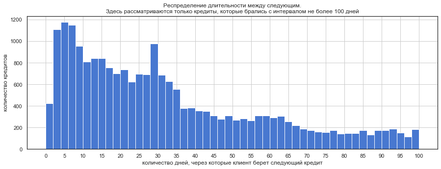

```python
interval_b_credit_ser.plot(kind='hist', bins=50, figsize=(15,5), range=(0,100), grid=True) #, density=False
plt.xticks(np.arange(0, 101, 5))
plt.title('Респределение длительности между следующим.\nЗдесь рассматриваются только кредиты, которые брались с интервалом\
 не более 100 дней')
plt.ylabel('количество кредитов')
plt.xlabel('количество дней, через которые клиент берет следующий кредит')
plt.savefig('img\\loans_break_distribution.png', format='png')
plt.show()
```

### 3.4. Статистика по повторным кредитам, продолжение

Рассматриваются только, те кредиты, интервал между началом одного и началом следующего составляет не более 100 дней.

```python
cr_interval[cr_interval <= timedelta(days=100)].describe()
```

```
count                      21827
mean     31 days 20:09:05.599486
std      25 days 11:00:13.420999
min              1 days 00:00:00
25%             11 days 00:00:00
50%             26 days 00:00:00
75%             47 days 00:00:00
max            100 days 00:00:00
Name: DateBegin, dtype: object
```

## 4. Временной перерыв между кредитами (отдых)

Имеется ввиду ситуация, когда у клиента были какие-то кредиты в ломбарде, потом он их все погасил, и у него не осталось никакой задолженности. А дальше смотрим через сколько дней он опять обратился в ломбард и взял кредит.

Внизу представлена статистика, через сколько дней перерыва клиенты открывают новые кредиты, не имея перед этим никакой задолженности.

```python
deltas_df.describe()
```

|  | delta |
| --- | --- |
| count | 12387 |
| mean | 60 days 04:35:44.829256 |
| std | 72 days 12:28:58.625436 |
| min | 1 days 00:00:00 |
| 25% | 13 days 00:00:00 |
| 50% | 32 days 00:00:00 |
| 75% | 78 days 00:00:00 |
| max | 509 days 00:00:00 |

И таблицы видно, что из всего количества вышерассмотренных кредитов (39515) интервалов между кредитами, во время которых у клиента не было никакой задолженности перед ломбардом, было всего 12387 случаев.

### 4.1. Распределение временного перерывамежду кредитами

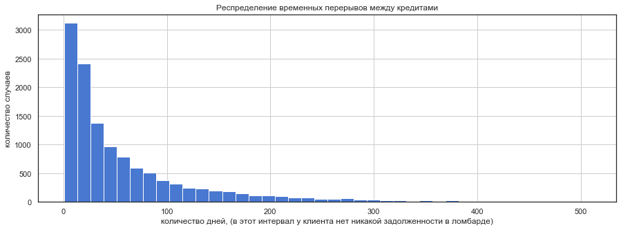

```python
deltas_ser.hist(bins=40, figsize=(15,5))
plt.title('Респределение временных перерывов между кредитами')
plt.xlabel('количество дней, (в этот интервал у клиента нет никакой задолженности в ломбарде)')
plt.ylabel('количество случаев')
plt.show()
```

### 4.2. Распределение перерывов между кредитами, продолжение

здесь рассматриваются перерывы не более 200 дней

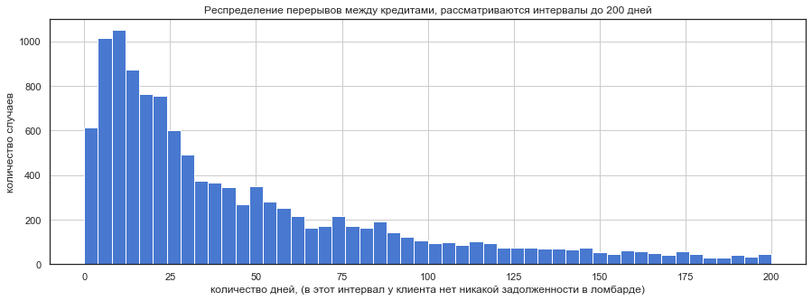

```python
deltas_ser.hist(bins=50, figsize=(15,5), range=(0,200), grid=True)
plt.title('Респределение перерывов между кредитами, рассматриваются интервалы до 200 дней')
plt.xlabel('количество дней, (в этот интервал у клиента нет никакой задолженности в ломбарде)')
plt.ylabel('количество случаев')
plt.show()
```

### 4.3. Распределение перерывов между кредитами, продолжение

здесь рассматриваются перерывы не более 100 дней

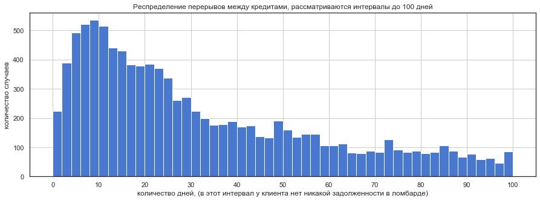

```python
deltas_ser.hist(bins=50, figsize=(15,5), range=(0,100), grid=True)
plt.xticks(np.arange(0, 101, 10))
plt.title('Респределение перерывов между кредитами, рассматриваются интервалы до 100 дней')
plt.xlabel('количество дней, (в этот интервал у клиента нет никакой задолженности в ломбарде)')
plt.ylabel('количество случаев')
plt.show()
```

### 4.4. Распределение перерывов между кредитами, продолжение

Рассмотрим статистику для кредитов интервалами между кредитами до 100 дней

```python
deltas_df[deltas_df <= timedelta(days=100)].describe()
```

|  | delta |
| --- | --- |
| count | 10093 |
| mean | 31 days 15:24:56.997919 |
| std | 25 days 17:08:23.506380 |
| min | 1 days 00:00:00 |
| 25% | 11 days 00:00:00 |
| 50% | 23 days 00:00:00 |
| 75% | 48 days 00:00:00 |
| max | 100 days 00:00:00 |